# Лабораторная работа №7

Адресация IPv4 и IPv6. Настройка DHCP / DHCPv6

Авдадаев Джамал Геланиевич

20 декабря 2025

# Цель работы

## Цель

Получить навыки настройки службы DHCP на сетевом оборудовании для распределения адресов IPv4 и IPv6:

- DHCP (IPv4)
- DHCPv6 Stateless (SLAAC + доп. параметры)
- DHCPv6 Stateful (выдача IPv6-адресов)

# DHCP для IPv4

## Топология IPv4

- Сегмент: PC1 → sw-01 → gw-01
- Шлюз: 10.0.0.1/24
- Клиент получает параметры по DHCP

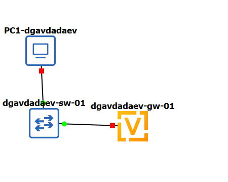

Топология сети в GNS3

## Базовая настройка VyOS

- Заданы host-name и domain-name
- Создан пользователь dgavdadaev
- Отключён DHCP на eth0

[figure not shown]

Базовая системная настройка VyOS

## Адресация и DHCP-сервер (IPv4)

- eth0: 10.0.0.1/24
- Пул: 10.0.0.2–10.0.0.253
- DNS/Router: 10.0.0.1

[figure not shown]

Настройка адресации и DHCP-сервера на VyOS

## Получение параметров на PC1 (DHCP)

- Назначен IP: 10.0.0.2/24
- Lease Time: 86400 секунд
- Выданы: DNS, шлюз, домен

[figure not shown]

Получение параметров по DHCP на VPCS

## Проверка конфигурации и связности

- show ip подтверждает параметры
- Шлюз: 10.0.0.1
- ping 10.0.0.1 успешен

[figure not shown]

Проверка IPv4-параметров и ping маршрутизатора

## DHCP-статистика и аренды (VyOS)

- Pool size: 252
- Active leases: 1
- Клиент: 10.0.0.2 (VPCS)

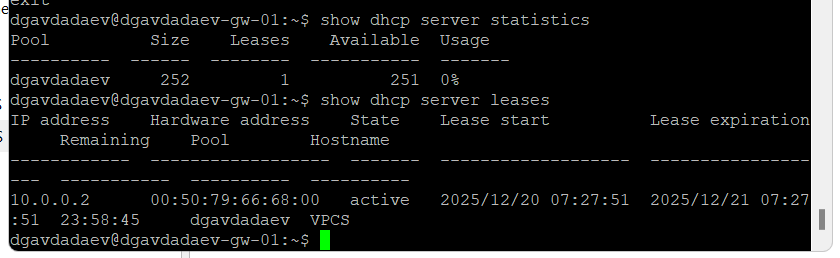

Статистика DHCP-сервера и активные аренды

## Лог DHCP-сервера

- Discover → Offer
- Request → ACK
- Назначение адреса подтверждено

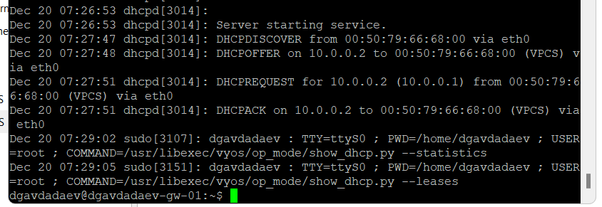

Журнал работы DHCP-сервера

## Анализ DHCP-трафика (Wireshark)

- Последовательность DORA
- Опции: mask/router/DNS/domain/lease
- Корректная выдача параметров

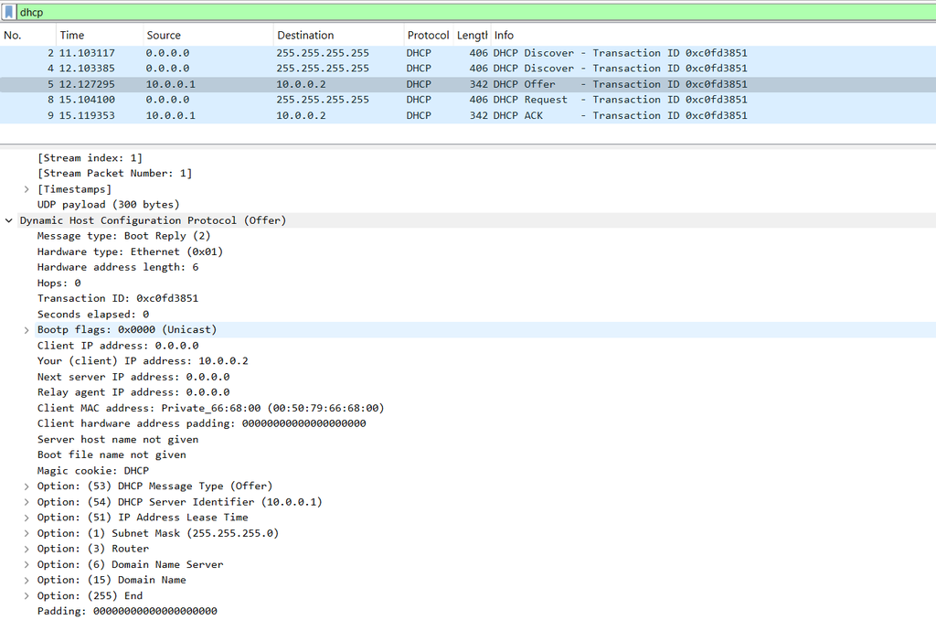

DHCP в Wireshark

# DHCPv6 Stateless

## Расширенная топология для IPv6

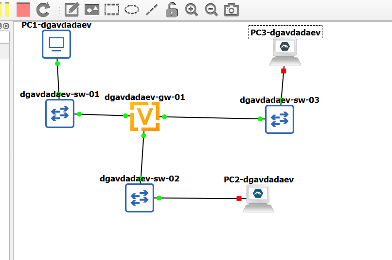

Топология IPv6

## IPv6-адресация интерфейсов VyOS

- eth1: 2000::1/64
- eth2: 2001::1/64
- Проверка через show interfaces

[figure not shown]

Назначение IPv6 на eth1/eth2

## Stateless: RA + DHCPv6 (настройка)

- RA prefix 2000::/64 (eth1)
- other-config-flag: доп. параметры через DHCPv6
- DHCPv6: DNS 2000::1 и domain-search

[figure not shown]

Команды настройки DHCPv6 Stateless

## Stateless: проверка конфигурации (VyOS)

- В конфигурации присутствуют dhcpv6-server и router-advert
- Shared-network-name: dgavdadaev-stateless
- Передаются общие опции (DNS, domain-search)

[figure not shown]

Фрагмент конфигурации DHCPv6 Stateless

## PC2: IPv6-автоконфигурация (SLAAC)

- Получен глобальный адрес из 2000::/64
- Есть link-local fe80::/64
- Маршрут по умолчанию через RA

[figure not shown]

IPv6 и маршруты на PC2

## PC2: проверка связности

- ping 2000::1 успешен
- Подтверждена работа RA/SLAAC
- Доступность шлюза обеспечена

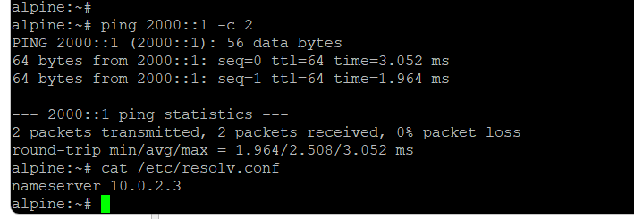

Ping 2000::1 с PC2

## PC2: DNS-параметры (Stateless)

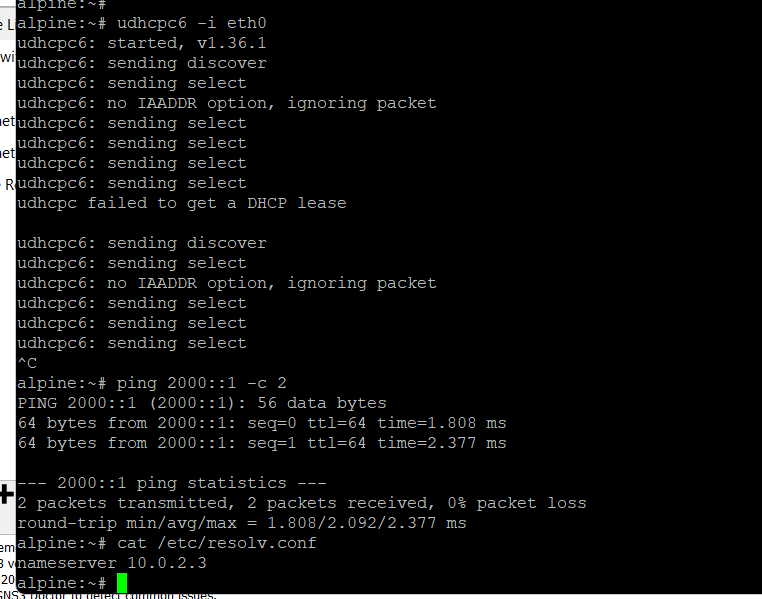

DNS на PC2

## Stateless: аренды DHCPv6 на VyOS

- Таблица leases без выданных IPv6-адресов
- Stateless не распределяет адреса
- DHCPv6 используется для «неадресных» параметров

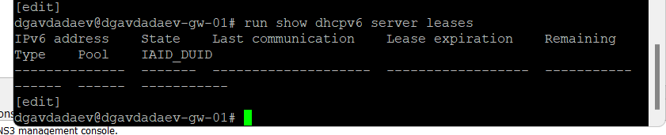

DHCPv6 leases (Stateless)

## Stateless: анализ трафика (Wireshark)

- Solicit/Reply для параметров
- IAADDR отсутствует (адрес не выдаётся)
- Адрес формируется по SLAAC

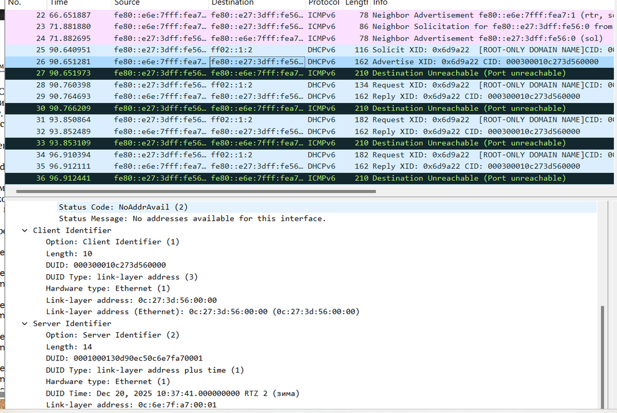

DHCPv6 Stateless в Wireshark

# DHCPv6 Stateful

## Stateful: настройка RA и DHCPv6 (eth2)

- managed-flag: адрес через DHCPv6
- Пул: 2001::100–2001::199
- DNS: 2001::1, domain-search: dgavdadaev.net

[figure not shown]

Команды настройки DHCPv6 Stateful

## Stateful: аренды DHCPv6 на VyOS

[figure not shown]

## PC3: состояние до DHCPv6

- Присутствует link-local адрес
- Маршрут по умолчанию через RA
- DNS ещё не задан по IPv6

[figure not shown]

## PC3: получение IPv6 по DHCPv6

[figure not shown]

## PC3: проверка после DHCPv6

[figure not shown]

## Stateful: анализ трафика (Wireshark)

- Solicit → Advertise → Request → Reply
- В Reply присутствует IA_NA (выдача адреса)
- Передаются DNS-параметры сервера

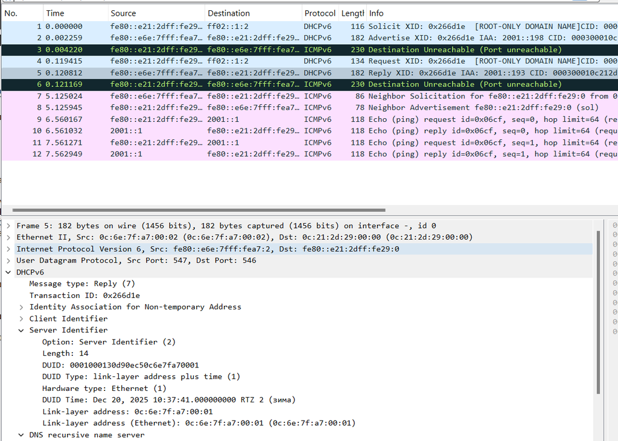

DHCPv6 Stateful в Wireshark

# Итоги